# DS 2020 - Summer 2025 - Homework #3

# Lab: Avengers’ Peril

## Overview

In this activity we are going to

1. reshape a data set, and then
2. use the data to fact-check some statistics in a published report.

## Data Background

The data was collected by FiveThirtyEight. This time we are interested in a review of life and death among the Avengers, a group of super heroes in the Marvel universe; the accompanying article is published [here](https://fivethirtyeight.com/features/avengers-death-comics-age-of-ultron/).

The description of the data is [here](https://github.com/fivethirtyeight/data/tree/master/avengers).

In a universe where time travel, alternate lifelines and portals with all kinds of powers exist, dying might be less permanent than in the world that we are used to.

In 2015 FiveThirtyEight has conducted a comprehensive review of all Avengers. We can access the resulting data using the command

```r
av <- read.csv("https://raw.githubusercontent.com/fivethirtyeight/data/master/avengers/avengers.csv", stringsAsFactors = FALSE)
head(av)
```

```
##                                                       URL
## 1           http://marvel.wikia.com/Henry_Pym_(Earth-616)
## 2      http://marvel.wikia.com/Janet_van_Dyne_(Earth-616)
## 3       http://marvel.wikia.com/Anthony_Stark_(Earth-616)
## 4 http://marvel.wikia.com/Robert_Bruce_Banner_(Earth-616)
## 5        http://marvel.wikia.com/Thor_Odinson_(Earth-616)
## 6       http://marvel.wikia.com/Richard_Jones_(Earth-616)
##                    Name.Alias Appearances Current. Gender Probationary.Introl
## 1   Henry Jonathan "Hank" Pym        1269      YES   MALE
## 2              Janet van Dyne        1165      YES FEMALE
## 3 Anthony Edward "Tony" Stark        3068      YES   MALE
## 4         Robert Bruce Banner        2089      YES   MALE
## 5                Thor Odinson        2402      YES   MALE
## 6      Richard Milhouse Jones         612      YES   MALE
##   Full.Reserve.Avengers.Intro Year Years.since.joining Honorary Death1 Return1
```

[output cut: 20 more lines]

## Data Tidying

The avenger data consists of ten columns for each avenger called Death[1-5] to Return[1-5]

Get the data into a format where the five columns for Death[1-5] are replaced by two columns: Time, and Death. Time should be a number between 1 and 5 (look into the function `parse_number()`); Death is a categorical variables with values “yes”, “no” and ““. Call the resulting data set `deaths`.

Similarly, deal with the returns of characters. Call the resulting data set `returns``

Answer the question: how many deaths on average, does an Avenger suffer?

## Fact Checking

Pick one of the statements in the FiveThirtyEight [analysis](https://fivethirtyeight.com/features/avengers-death-comics-age-of-ultron/) and fact check it based on the data. Use `dplyr` functionality whenever possible.

# Homework Assignment (Part 1)

## Flying etiquette

FiveThirtyEight is a website founded by Statistician and writer Nate Silver to publish results from opinion poll analysis, politics, economics, and sports blogging. One of the featured articles considers [flying etiquette](https://fivethirtyeight.com/features/airplane-etiquette-recline-seat/). This article is based on data collected by FiveThirtyEight and publicly available on github. Use the code below to read in the data from the survey:

```r
fly <- read.csv("https://raw.githubusercontent.com/fivethirtyeight/data/master/flying-etiquette-survey/flying-etiquette.csv")
```

The following couple of lines of code provide a bit of cleanup of the demographic information by reordering the levels of the corresponding factor variables. Run this code in your session.

```r
fly$Age <- factor(fly$Age, levels=c("18-29", "30-44", "45-60", "> 60", ""))
fly$Household.Income <- factor(fly$Household.Income, levels = c("$0 - $24,999","$25,000 - $49,999", "$50,000 - $99,999", "$100,000 - $149,999", "150000", ""))
fly$Education <- factor(fly$Education, levels = c("Less than high school degree", "High school degree", "Some college or Associate degree", "Bachelor degree",  "Graduate degree", ""))
```

1. Download the RMarkdown file with these homework instructions to use as a template for your work. Make sure to replace “Your Name” in the YAML with your name.
2. Some people do not travel often by plane. Provide a (visual) breakdown of travel frequency (use variable `How.often.do.you.travel.by.plane.`). Reorder the levels in the variable by travel frequency from least frequent travel to most frequent. Draw a barchart of travel frequency and comment on it. Exclude all respondents who never fly from the remainder of the analysis. How many records does the data set have now?

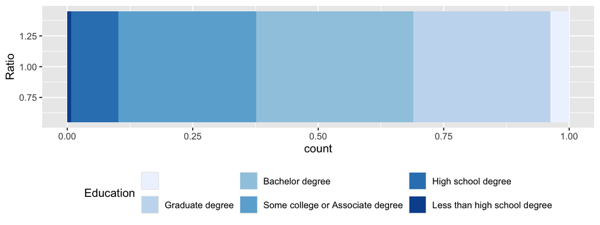

```r
library(ggplot2)
fly$Education = with(fly, factor(Education, levels = rev(levels(Education))))

ggplot(data = fly, aes(x = 1)) +
  geom_bar(aes(fill=Education), position="fill") +
  coord_flip() +
  theme(legend.position="bottom") +
  scale_fill_brewer() +
  xlab("Ratio")
```

# Homework Assignment (Part 2)

## Liquor Sales in Iowa

This dataset contains the spirits purchase information of Iowa Class “E” liquor licensees by product and date of purchase from January 1, 2017 to current. The dataset can be used to analyze total spirits sales in Iowa of individual products at the store level.

For all of the questions use functionality from the `tidyverse` whenever possible.

1. Download the RMarkdown file with these homework instructions to use as a template for your work. Make sure to replace “Your Name” in the YAML with your name.
2. The code below downloads the data from the Iowa Portal and saves a local copy to your machine. The first time you run this code, make sure you have a good internet connection and enough space on your machine (~50 MB). If the local copy exists, re-knitting the file will load the (binary) file from disk and be much faster.

```r
if (!file.exists("ames-liquor.rds")) {
  url <- "https://github.com/ds202-at-ISU/materials/blob/master/03_tidyverse/data/ames-liquor.rds?raw=TRUE"
  download.file(url, "ames-liquor.rds", mode="wb")
}
data <- readRDS("ames-liquor.rds")
```

3. Quick fact overview:
- how many observations are in `data`?

Note: Your submission is supposed to be fully reproducible, i.e. the TA and I will ‘knit’ your submission in RStudio.

For the submission: submit your solution in an R Markdown file and (just for insurance) submit the corresponding html (or Word) file with it.

(Optional but encouraged):  
If you’d like to practice using GitHub, feel free to push your `.Rmd` and knitted `.html` file to a **public GitHub repository** under your own account. If you do, paste the link to your GitHub repo below: